# Measurement Error in Psychological Science

Koen Neijenhuijs

08 jul, 2019

# Introduction

This page introduces the reasoning behind the unconference on Measurement Error during the meeting of the Society for the Improvement of Psychological Science 2019 in Rotterdam. The slides of the unconference can be found [here](https://kneijenhuijs.github.io/SIPS-2019-Measurement-Error/Measurement_error_slides.html).

Recently, I performed a systematic review on the measurement properties of a few dozen Patient Reported Outcome Measures (PROMs). After data extraction of 314 validation articles, we found a surprising lack of reports on measurement error. A total of 13 validation articles (4.14%) reported on measurement error, of which 9 reported a Standard Error of Measurement, 3 reported Limits of Agreement, and 2 reported Person Standard Error. For a total of 12 validation articles (3.82%) we could calculate Standard Error of Measurement and Smallest Detectable Change. As such, only 25 (7.96%) of all articles reported data relevant to Measurement Error.

Measurement Error represents the minimum amount of change measured by a measurement tool, of which we can be sure is not an artifact of systematic error. The amount of Measurement Error is ideally smaller than the Minimal Clinically Important Difference, which represents the minimum amount of change measured by a measurement tool, which is judged to be represent a clinically meaningful change for the patient. We want the Measurement Error to be smaller, so that we can be sure that when we measure a clinically meaningful change, it is not an error.

There are some formulas to cover. To calculate the SDC, we need two measurements of the instrument where the outcome should have been stable. So we need to start with a reliability testing set-up. The formula for the SDC is related to the formula for the Intraclass Correlation Coefficient:

$$Reliability = {\sigma^2 participants \over \sigma² participants + \sigma² error}$$
First, we need the Standard Error of Measurement (SEM), which is the root of the error term in the formula of reliability:

$$Standard\, Error\, of\, Measurement = \sqrt {\sigma² error}$$

In practice, we calculate the SEM as follows:

$$Standard\, Error\, of\, Measurement = SD * \sqrt {1-ICC}$$

Then the Smallest Detectable Change (SDC) is calculated by taking the outer 5% of the distribution of the SEM:

$$Smallest\, Detectable\, Change = 1.96 * \sqrt {2} * SEM$$

This formula can also be specified as:

$$Smallest\, Detectable\, Change = 1.96 * SD_{change}$$

This last formula is equal to the Limits of Agreement, on which the Bland-Altman method is derived. I won’t go into detail on this method in this text. A nice write-up of this method can be found [here](https://doi.org/10.1093/bja/aem214) (Myles and Cui 2007).

Given the above definition, it is clear that Measurement Error has large implications for both clinical practice (e.g. “did the patient improve / deteriorate over time?”) as well as research settings (e.g. “is the change caused by our intervention large enough to warrant implementation?”). To illustrate the latter, I drafted a simulation to represent a research setting close to my own field.

## Simulation justification

I am simulating a RCT for the treatment of depression, with depression being measured by the BDI-II. Why the BDI-II? Because I could find some nifty statistics on it to make the simulation more rooted in reality.

The BDI-II has a range of 0 - 63, which can be categorized into four categories:

1. 0-13: minimal depression
2. 14-19: mild depression
3. 20-28: moderate depression
4. 29-63: severe depression

A systematic review from 2013 provided me with data on baseline means and standard deviations of clinical samples (Wang and Gorenstein 2013). I pooled these means and standard deviations, which resulted in a pooled baseline mean of 24.1 and pooled baseline sd of 11.4. These numbers will be used to represent our fixed intercept in the data generation.

Measurement error was added based on a percentage of the range of the BDI-II. In my experience (and that of some colleague psychometricians I asked, #AnecdotalEvidence) a Smallest Detectable Change representing 20% of the range of the measurement instrument is a regular finding. As such, I decided to use measurement error ranging from 0% up to 40%.

## Code explanation

I’m going to walk through the code step by step. I am using the SimDesign package (Chalmers 2019) to simplify the steps. The steps consist of data generation, data analysis, and summarizing the results.

### Data generation

The first step is defining the design:

```r
Design <- expand.grid(sampleSize = c(250, 500, 750),
                      effectSize = c(0*4.338, 1*4.338, 2*4.338, 3*4.338),
                      measError = c(0, 0.1, 0.2, 0.3, 0.4))
```

These are the parameters I discussed previously. The effect size is based on a multiplication of the MCID (4.338), while the measurement error is based on a percentage of the range. Furthermore, I wanted to check the influence of sample size. I actually also wanted to include small sample sizes (< 100), but I couldn’t get the models based on that data generation to converge in the analysis phase.

I’m going to go step by step through the data generation function.

```r
# Function that generates the data
Generate <- function(condition, fixed_objects=NULL) {
  Attach(condition) # So I don't have to type "condition$" in front of every element in our design
  # Generate measurement error as percentage of total possible value of BDI-II. Example: if Measurement Error = 0.1 (10% of range), the mean of the measurement error distribution is 0.1*63=6.3.
  r <- 0.5 # Intra-individual correlation of measurement error
  Sigma <- matrix(c((3.214286)^2, r, r, (3.214286)^2),nrow=2) # Covariance matrix
  measurementError <- rmvnorm(sampleSize, mean=c(measError*63,measError*63), sigma=Sigma)
  measSign <- rbinom(sampleSize, 1, prob=c(0.5,0.5)) # random binomial to make measurement error randomly positively or negatively signed
  measSign[measSign==0] <- -1 # Change zero to -1 for sign
  measurementError <- measurementError * measSign # Apply sign
  measurementErrorDat <- data.frame(id = sort(rep(c(1:sampleSize))),
                                    Pre = measurementError[,1],
                                    Post = measurementError[,2]) %>% gather("time", "measurementError", -id)
```

Above, I generate the measurement error and put it into a data frame. I’m going to have to explain the Sigma, and my justifications. To be honest, this is where I couldn’t find strong justifications for settings. I picked an intra-individual correlation of measurement error (the correlation between the measurement error at baseline and endline) of 0.5. Honestly, this could be anything. Next, the number 3.214286 might seem very random. I actually chose to take 10% of the BDI-II range (6.3) to represent 1.96*sd. This low number was chosen to create a conservative variance of measurement error. Basically, this ensures that the data generation doesn’t create large deviations from the set measurement error mean. These parameters are super arbitrary, and I haven’t checked how much they influence the results.

```r
  # Random effects
  i <- 0.2 # sd intercepts
  s <- 0.5 # sd slopes
  r <- 0.8 # correlation between intercepts and slopes

  # This calculates the random effects
  cov.matrix1 <- matrix(c(i^2, r * i * s, r * i * s, s^2), nrow = 2, byrow = T)
  randomEffects <- rmvnorm(sampleSize, mean = c(0, 0), sigma = cov.matrix1)
```

Next, we generate the random intercept and random slope for each individual in our data set. Again, these parameters for Sigma are super-arbitrary. But through experimentation in the past, I found these parameters to create decent random effects.

```r
  # Alpha = 24.1 + random intercept
  # Beta = 9.828 (+ time effect for treatment group) + random slope
  indDf <- data.frame(id = c(1:sampleSize),
                      condition=c(rep('Treatment', sampleSize/2), rep('Control', sampleSize/2))) %>%
    mutate(alpha = 24.1+randomEffects[, 1],
           beta = ifelse(condition=="Treatment", -(9.828+effectSize+randomEffects[, 2]), -(9.828+randomEffects[, 2])))
```

Then I create a data frame with the intercept and slope for each individual in the data set. The intercept is the fixed intercept (24.1) plus the random intercept of each individual. The slope is the fixed slope plus the random slope of each individual. Depending on the condition, the fixed slope is either -9.828 (Control) or -(9.828+effectSize).

```r
  timeContrast = c(0,1)
  withinDf <-  data.frame(id = sort(rep(c(1:sampleSize), 2)),
                          time=c(rep(c('Pre', 'Post'), sampleSize)),
                          x=rep(timeContrast, 2))

  dat <- merge(indDf, withinDf) %>% merge(measurementErrorDat) %>% mutate(DV = alpha + x * beta + measurementError)
```

I create a data frame representing the two measurements, merge it with the data frame with the individual intercepts and slopes, and then calculate the dependent variable as: `intercept + time * slope + measurement error`.

```r
  # Truncate to 0 or 63
  dat$DV[dat$DV<0] <- 0
  dat$DV[dat$DV>63] <- 63

  dat
}
```

Lastly, I truncate any values that went below 0 or above 63 (even though scores above 63 should be nigh impossible, best be sure). The function then returns the generated data frame.

### Data analysis

```r
# Function for analysing the data set
Analyse <- function(condition, dat, fixed_objects=NULL){
  Attach(condition) # So I don't have to type "condition$" in front of every element in our design
  fit <- lmer(DV ~ condition * time + (1 | id), data=dat) # Model fit
  singular <- isSingular(fit) # Check to see whether the fit is singular
  sig <- Anova(fit) # Significance test
  anova <- ezANOVA(dat, dv=.(DV), wid=.(id), within=.(time), between=.(condition)) # RM ANOVA to calculate eta squared
  ret <- data.frame(coefficientInt=coef(summary(fit))[4,1], seInt=coef(summary(fit))[4,2], pInt=sig$`Pr(>Chisq)`[3], etaInt=anova$ANOVA$ges[3],
                    singular=as.numeric(singular), effect_Size=as.numeric(effectSize)) # Extract Coefficients, standard errors, significance, and eta squared
  ret
}
```

The data analysis function is much simpler. I fit a linear mixed-effect model, check whether the fit is singular (happens sometimes, and I’d rather have the information on how often it happened), run a significance test, and run a RM ANOVA to get an ETA². Next, all relevant information (coefficient, SE, p-value, ETA² and singularity) is put into a data frame, which the function returns. I also catch the effect size here, as I need it in my summarise function.

### Summarise

```r
# Function that summarises the analysis results into useful statistics for examining which of the data sets showed less bias
Summarise <- function(condition, results, fixed_objects = NULL) {
  bias_Int <- bias(results$coefficientInt, parameter=results$effect_Size, type="relative") # Relative bias summary statistic for the Interaction coefficient
  MAE_Int <- MAE(results$coefficientInt, parameter=results$effect_Size) # Mean absolute error for the Interaction coefficient
  RMSE_Int <- RMSE (results$coefficientInt, parameter=results$effect_Size) # Root Mean Square Error for the Interaction coefficient
  SE_Int <- mean(results$seInt, na.rm=TRUE) # Mean Standard Error of Interaction
  EDR_Int <- EDR(results$pInt, alpha=.05) # Type I errors and Power for Interaction
  ETA_Int <- mean(results$etaInt, na.rm=TRUE) # Mean Eta²

  sing <- sum(results$singular, na.rm=TRUE) # How often was the fit singular?

  ret <- data.frame(bias_Int=bias_Int, MAE_Int=MAE_Int, RMSE_Int=RMSE_Int, SE_Int=SE_Int, ETA_Int=ETA_Int, EDR_Int=EDR_Int,
                    singular=sing, int=int)
  ret
}
```

The summarise function calculates values that I’m interested in for interpretation of the resuls. I calculate a relative bias, the mean absolute error, and Root Mean Square Error. The calculation of these three values is why I had to return the effect size in the analysis function, so they can be compared to the intended value of the interaction effect. Next, I also calculate a mean Standard Error of the coefficient, Empirical Detection Rates, a mean ETA² and a sum of how often singularity occured. Again, this is all put neatly into a data frame that is returned by the function.

### Running the simulation

```r
# Run the simulation
results <- runSimulation(Design, replications=5000, verbose=FALSE, parallel=TRUE, ncores=5, progress=TRUE, save=TRUE,
                         packages=c('tidyverse', 'ez', 'lme4', 'car'),
                         generate=Generate, analyse=Analyse, summarise=Summarise)
```

The easiest part of the code, the above runs the simulation.

## Results

All the above code was not run during the creation of this markdown file (could you imagine how long it would take, only for me to find a typo or two?), so first we load our relevant libraries and the result data.

```r
library(here)
library(ggplot2)
library(ggthemes)
library(tidyverse)
results <- readRDS(here("results.rds"))
```

### Relative bias

The relative bias is the bias of the coefficient of interest. The bias is divided by the value of the coefficient used in the data generation. We expect that with more measurement error, this bias becomes larger.

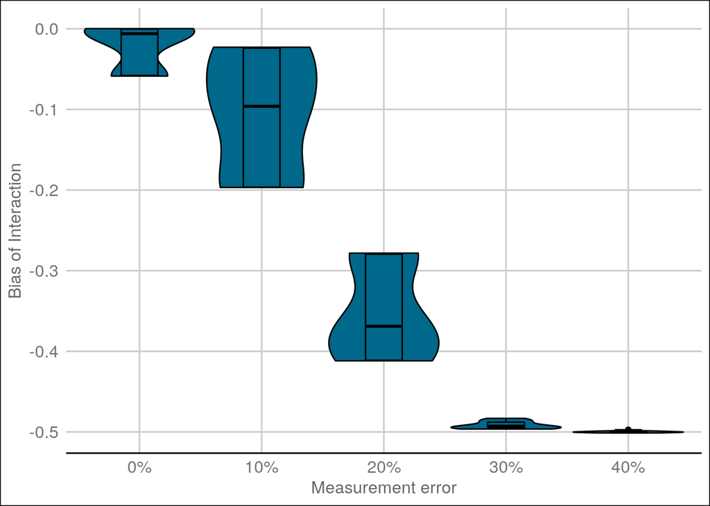

```r
ggplot(results, aes(x=measError, y=bias_Int)) +
  geom_violin(scale="width", color="black", position = position_dodge(width = 0.9), fill="deepskyblue4") +
  geom_boxplot(color="black", position = position_dodge(width = 0.9), show.legend = FALSE, width=0.3, fill="deepskyblue4") +
  labs(color="Mean effect", x="Measurement error", y="Bias of Interaction") +
  scale_x_discrete(labels=c("0%", "10%", "20%", "30%", "40%")) +
  theme_gdocs()
```

As you can see, our interaction coefficient becomes biased from near zero (with no measurement error) to -0.5 (with 30% and 40% measurement error). A clear and also very predictable result: More measurement error creates more bias in our coefficient. How does this relate to effect size?

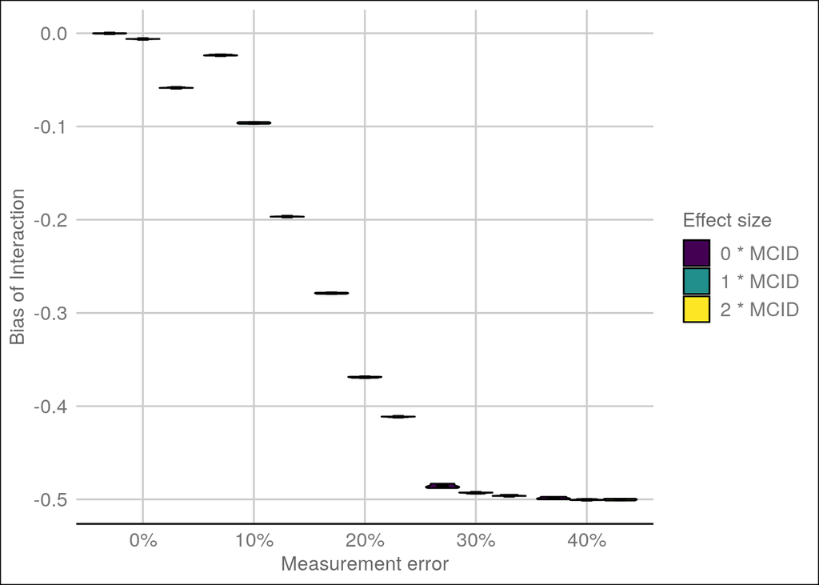

```r
ggplot(results, aes(x=measError, y=bias_Int, fill=effectSize)) +
  geom_violin(scale="width", color="black", position = position_dodge(width = 0.9)) +
  geom_boxplot(color="black", position = position_dodge(width = 0.9), show.legend = FALSE, width=0.3) +
  labs(x="Measurement error", y="Bias of Interaction") +
  scale_x_discrete(labels=c("0%", "10%", "20%", "30%", "40%")) +
  scale_fill_viridis_d(name = "Effect size", labels = c("0 * MCID", "1 * MCID", "2 * MCID", "3 * MCID")) +
  theme_gdocs()
```

Oh my, very little variance within the violin plots, but we can tell that higher effect sizes seem to show more bias in the interaction coefficient.

### Mean Absolute Error

The Mean Absolute Error is the average absolute deviation from the coefficient. It is similar to the relative bias, except that it is, well, an absolute measure rather than relative.

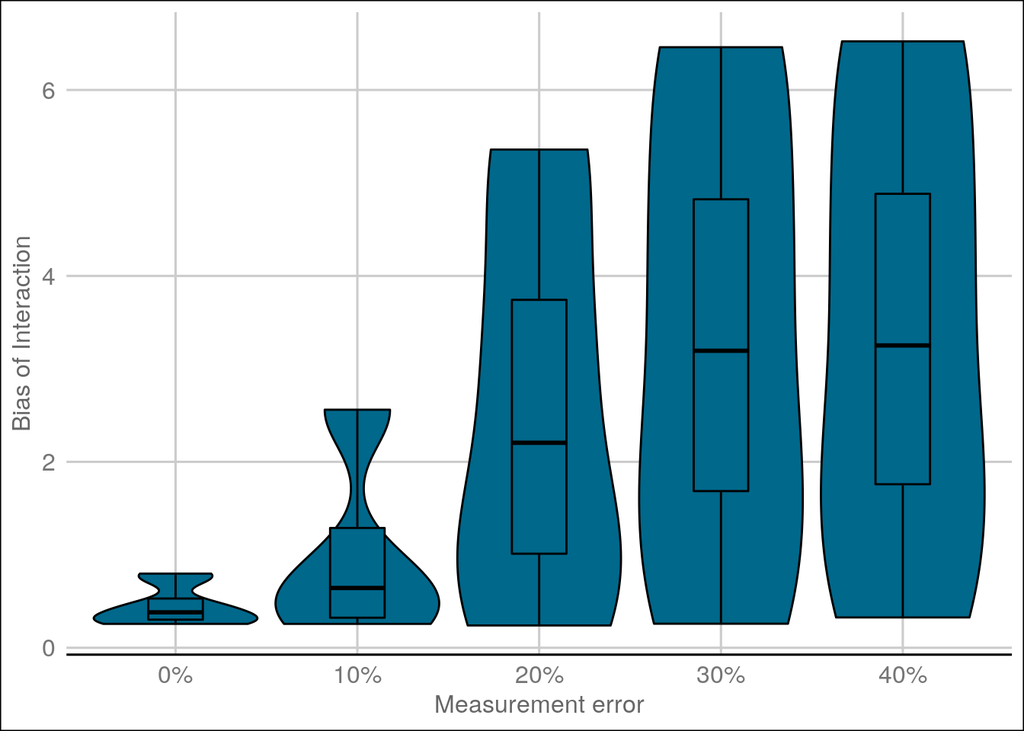

```r
ggplot(results, aes(x=measError, y=MAE_Int)) +
  geom_violin(scale="width", color="black", position = position_dodge(width = 0.9), fill="deepskyblue4") +
  geom_boxplot(color="black", position = position_dodge(width = 0.9), show.legend = FALSE, width=0.3, fill="deepskyblue4") +
  labs(color="Mean effect", x="Measurement error", y="Bias of Interaction") +
  scale_x_discrete(labels=c("0%", "10%", "20%", "30%", "40%")) +
  theme_gdocs()
```

The interaction coefficient becomes biased from near zero (with no measurement error) to over 6 (with 30% and 40% measurement error). Please note, 6 is a lot as our coefficient ranges from 0 to 13! Let’s check it out in relation to effect size.

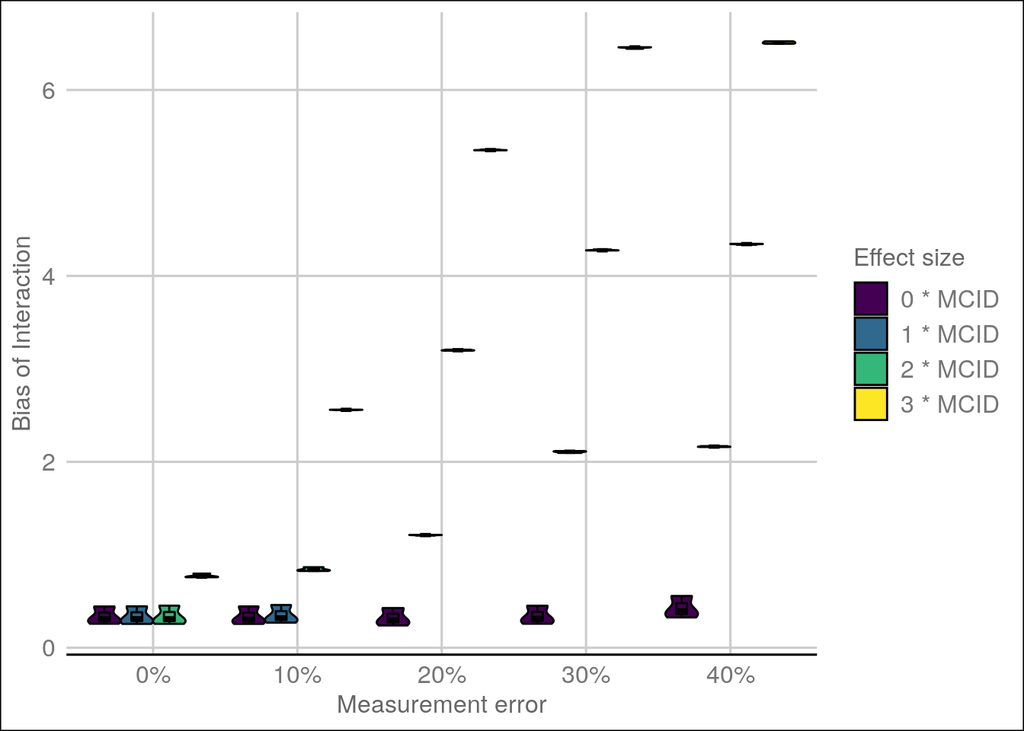

```r
ggplot(results, aes(x=measError, y=MAE_Int, fill=effectSize)) +
  geom_violin(scale="width", color="black", position = position_dodge(width = 0.9)) +
  geom_boxplot(color="black", position = position_dodge(width = 0.9), show.legend = FALSE, width=0.3) +
  labs(x="Measurement error", y="Bias of Interaction") +
  scale_x_discrete(labels=c("0%", "10%", "20%", "30%", "40%")) +
  scale_fill_viridis_d(name = "Effect size", labels = c("0 * MCID", "1 * MCID", "2 * MCID", "3 * MCID")) +
  theme_gdocs()
```

We can tell that measurement error really seems to have more influence when the effect size is larger. I honestly thought we would see more absolute bias when there was no effect size.

### Mean Standard Error of coefficient

The Mean Standard Error I am plotting here is literally the mean of the SE that is reported when your perform the Linear Mixed-Model showed in the Analyse function. I don’t necessarily expect it to go up, but mostly that the distribution gets more spread out when measurement error goes up.

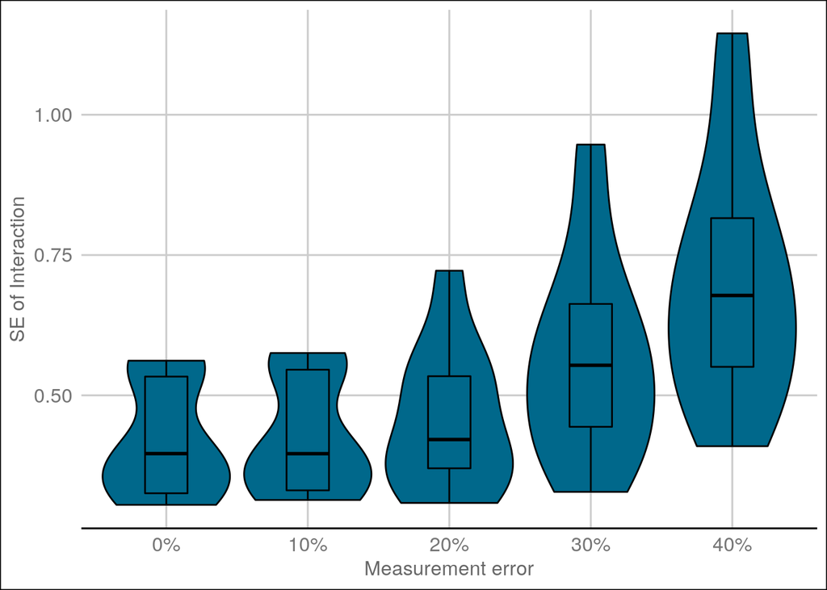

```r
ggplot(results, aes(x=measError, y=SE_Int)) +
  geom_violin(scale="width", color="black", position = position_dodge(width = 0.9), fill="deepskyblue4") +
  geom_boxplot(color="black", position = position_dodge(width = 0.9), show.legend = FALSE, width=0.3, fill="deepskyblue4") +
  labs(color="Mean effect", x="Measurement error", y="SE of Interaction") +
  scale_x_discrete(labels=c("0%", "10%", "20%", "30%", "40%")) +
  theme_gdocs()
```

So it goes up a bit, but mostly shows a broader distribution. The SE is a measure of our uncertainty regarding our coefficient, so that makes sense! Let’s check out the relation to effect size.

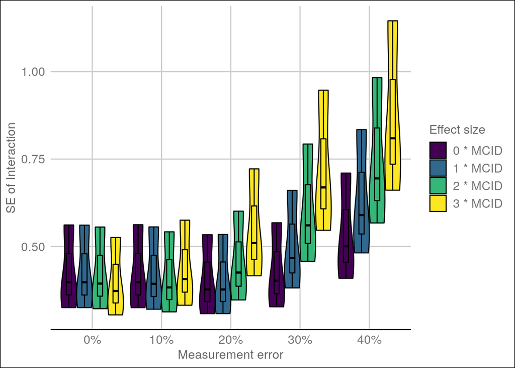

```r
ggplot(results, aes(x=measError, y=SE_Int, fill=effectSize)) +
  geom_violin(scale="width", color="black", position = position_dodge(width = 0.9)) +
  geom_boxplot(color="black", position = position_dodge(width = 0.9), show.legend = FALSE, width=0.3) +
  labs(x="Measurement error", y="SE of Interaction") +
  scale_x_discrete(labels=c("0%", "10%", "20%", "30%", "40%")) +
  scale_fill_viridis_d(name = "Effect size", labels = c("0 * MCID", "1 * MCID", "2 * MCID", "3 * MCID")) +
  theme_gdocs()
```

A higher effect size doesn’t necessarily gives a more spread out distribution, but the SE does go up.

### ETA Squared

ETA Squared is a measure of effect size. We expect the ETA Squared to deviate away from the “expected” ETA Squared given how large the coefficient is. I’m not a 100% sure how large the ETA squared should be given the size of the coefficient, so our 0% measurement error serves as our comparison unit. While the plot including the sizes of the coefficient is more informative, I do want to show the plot without them first.

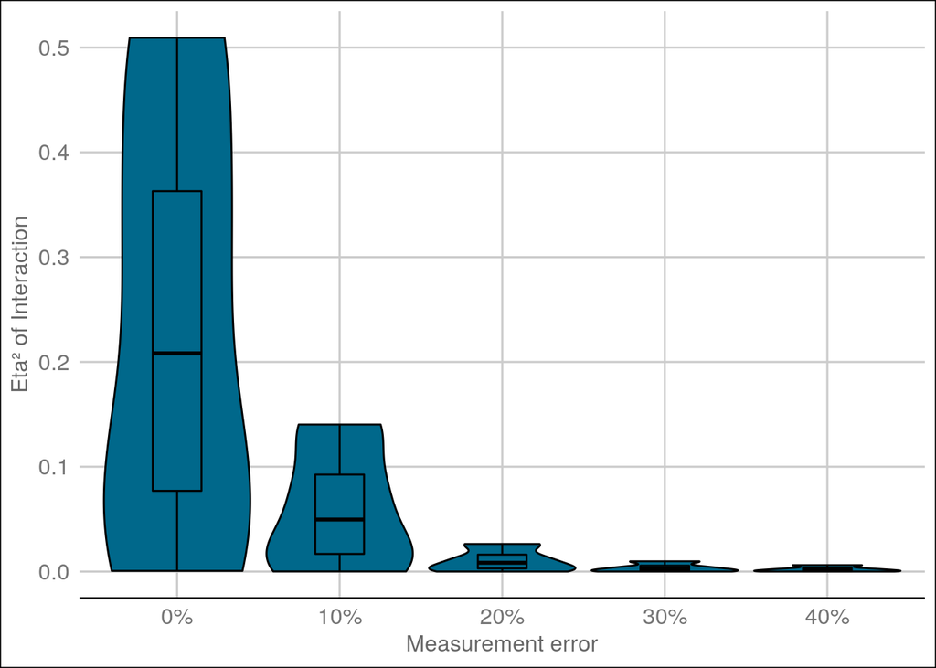

```r
ggplot(results, aes(x=measError, y=ETA_Int)) +
  geom_violin(scale="width", color="black", position = position_dodge(width = 0.9), fill="deepskyblue4") +
  geom_boxplot(color="black", position = position_dodge(width = 0.9), show.legend = FALSE, width=0.3, fill="deepskyblue4") +
  labs(color="Mean effect", x="Measurement error", y="Eta² of Interaction") +
  scale_x_discrete(labels=c("0%", "10%", "20%", "30%", "40%")) +
  theme_gdocs()
```

With 0% measurement error, we see a nice distribution of ETA Squared, which makes sense as this is an aggregate of all the simulations regardless of coefficient size. The more measurement error we add, the further ETA Squared deviates towards zero.

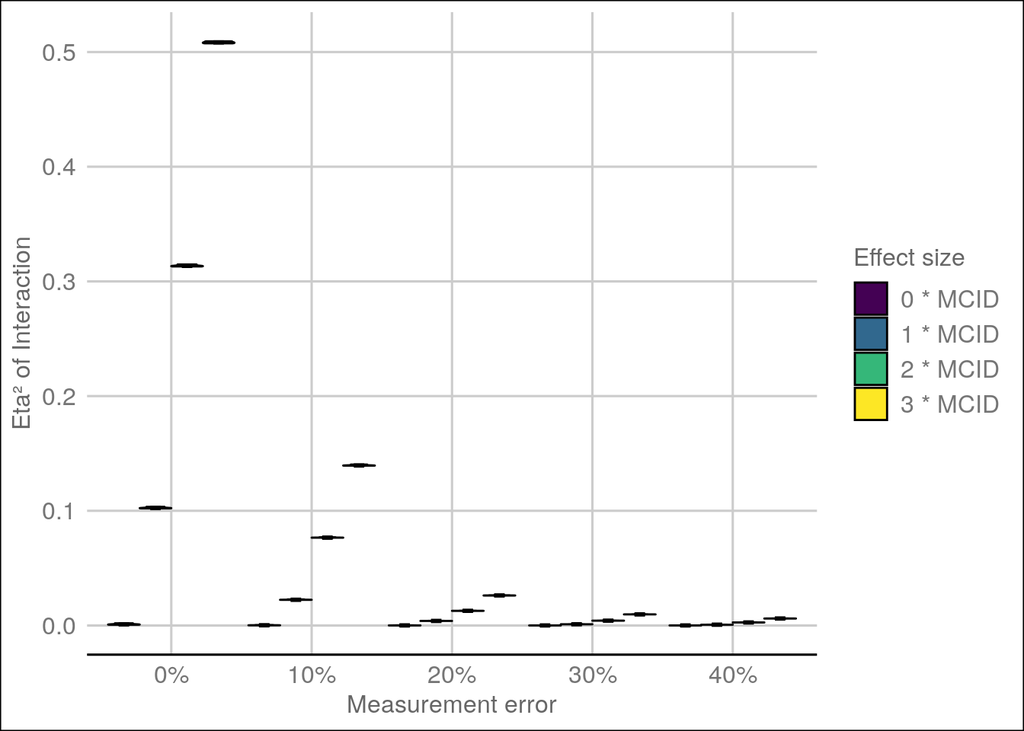

```r
ggplot(results, aes(x=measError, y=ETA_Int, fill=effectSize)) +
  geom_violin(scale="width", color="black", position = position_dodge(width = 0.9)) +
  geom_boxplot(color="black", position = position_dodge(width = 0.9), show.legend = FALSE, width=0.3) +
  labs(x="Measurement error", y="Eta² of Interaction") +
  scale_x_discrete(labels=c("0%", "10%", "20%", "30%", "40%")) +
  scale_fill_viridis_d(name = "Effect size", labels = c("0 * MCID", "1 * MCID", "2 * MCID", "3 * MCID")) +
  theme_gdocs()
```

### Empirical Detection Rates

This is probably my favorite figure to check. The EDR shows how often we get a *p* of .05 when there is no effect. As such, this only plots the condition where there is no effect size. Basically: How likely are Type I errors when measurement error increases?

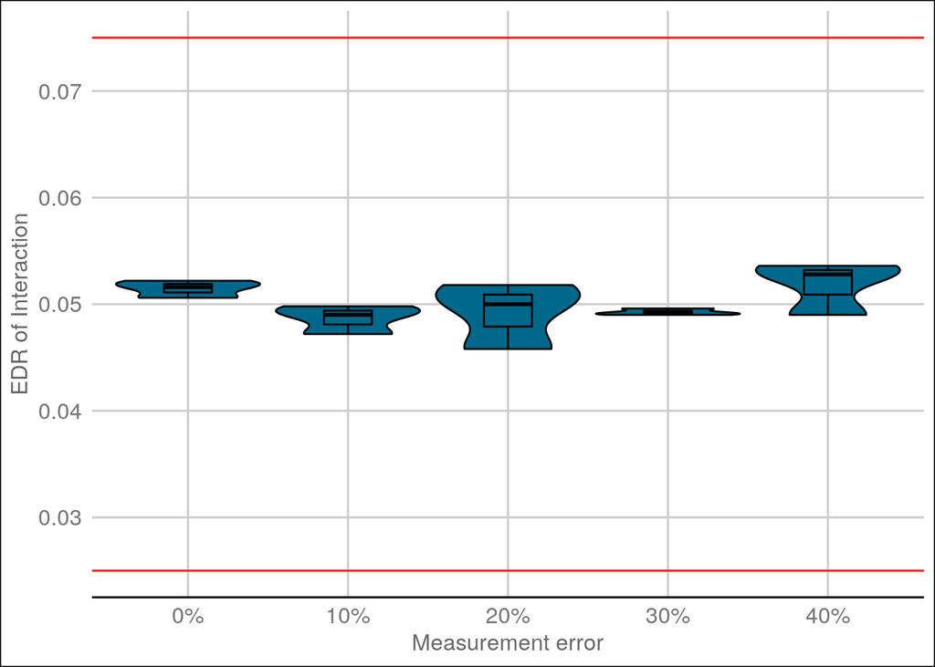

```r
ggplot(results %>% filter(effectSize==0), aes(x=measError, y=EDR_Int)) +
  geom_violin(scale="width", color="black", position = position_dodge(width = 0.9), fill="deepskyblue4") +
  geom_boxplot(color="black", position = position_dodge(width = 0.9), show.legend=FALSE, width=0.3, fill="deepskyblue4") +
  labs(color="Mean effect", x="Measurement error", y="EDR of Interaction") +
  scale_x_discrete(labels=c("0%", "10%", "20%", "30%", "40%")) +
  geom_hline(yintercept = .075, colour = 'red') + geom_hline(yintercept = .025, colour = 'red') +
  theme_gdocs()
```

My response to this figure was “huh”, as there is no very obvious trend with an increase in measurement error.

## Simulation limitations

I need to point out some limitations to the simulation in its’ current form. All of the limitations are related to how the data is generated.

1. A lot of parameters in the data generation are super-arbitrary. In particular, the calculation of the variance-covariance matrix for generation of the measurement error has multiple parameters that can be improved upon. The inta-individual correlation can be improved by finding any justification for a certain value. Whule the variance of the measurement error has some justification, it is all based on personal logic, instead of literature. The parameters in the variance-covariance matrix for generation of the random effects are equally (if not more) arbitrary.
2. The analysis of the data sets based on zero measurement error result in a lot of singular models (i.e. models where the random effects are close to zero). This might actually be the explanation for why I found no trend in Empirical Detection Rates. I tried adding some more random error to the data generation, but this created an unreasonably high amount of data points that equal zero on the BDI-II, which is not realistic.
3. On the subject of error, the data generation definitely needs some as random effects and measurement error are definitely not the only sources of error in data. Like I stated, I tried adding some more random error to the data generation, but this created an unreasonably high amount of data points that equal zero on the BDI-II, which is not realistic.

If anybody have any suggestions for fixing these limitations, please contact me!

# Discussion

The discussion focused mostly on ways to correct for measurement error. A number of suggestions were made, to which I will add my own response (which I either gave throughout the session or came up with later).

Andre Wang mentioned the use of the Spearman’s correction for attenuation (1904). Sam mentioned how it is not ideal, due to imprevision. A recent paper showed how mixed-effect models outperform Spearman’s correction through estimation of random effects *(am waiting for the reference from Sam)*.

An issue was noted for social psychology particularly. Most papers create or at least heavily modify existing measurement tools/experimental tasks. The question asked was “how can we even assess measurement properties if that is the case?”. Bad news, you need dedicated validation studies. If this is a field-wide issue, that is a hell of a task to tackle. In this case, guidelines for how to conduct validation studies can help out immensely. And while such guidelines exist for questionnaires, I am not aware of guidelines for more experimental measures. This is a knowledge gap waiting to be filled.

A short observation: during the unconference it became abundantly clear that if you run an experimental task, you need to analyse using a form of mixed-effect modeling to estimate random variance (both on the participant and item-level). So far, this seems the most reliable (pun intended) analysis method to have internal consistency/splithalf reliability be part of your model (through the variance-covariance matrix of the random effects).

One suggestion was offered for measurement properties to be discussed during peer review. What measures were used? What is known in the literature on the measurement properties of these measures? What measurement properties did you find in your sample? This last question is particularly important, as the generalization of measurement properties is an assumption that does not hold true in practice. I feel like this suggestion combines well with the more wide suggestion that peer review should include at least one statistician who is familiar with the analysis methods used. Something which has been mentioned as early as 2006 (Ozonoff 2006), but unfortunately has not yet seen wide implementation.

My favorite suggestion from the room: How about a database of measurement properties, to which anyone can upload their data as well as the measurement properties they found in that data? This is the holy grail, but I’m skeptical towards the feasibility. Another project at SIPS is the [scienceverse of Lisa DeBruine and Daniël Lakens](https://docs.google.com/document/d/1DKhnypsG__XG9k_16smU3IJDYGgnxFP5LHw4P6Qh50g/). They aim to create easy-to-use tools for researchers to create a machine-readable summary of their project. In a project such as this, measurement properties could be a part of the generated summary. Furthermore, through integration with open data databases (e.g. OSF), large datasets could be formed (or found) on which independent researchers could run validity/reliability analyses. The large issue is the need for standardization and centralization of practices, which is a large roadblock to overcome.

I made one suggestion which believe is feasible, but was met with fair skepticism from the room. The suggestion is to have researchers run validation/reliability analyses on datasets that they have already collected. While I made the suggestion that certain analyses can be performed on most datasets and are relatively easy to perform, the room was not convinced. The issue raised was that for validation analyses a large number of expert decisions are necessary. While I agree with this notion, there are certain analyses that do not have to be complicated for them to add to our knowledge. For example, if you have a questionnaire with three subscales, a Confirmatory Factor Analysis can be used to test whether those subscales fit to the data, using accessible R packages, and these days even [using JASP](https://jasp-stats.org/2018/07/03/how-to-perform-structural-equation-modeling-in-jasp/). I agree, that when you have a bad fit to the data, and want to explore alternative factor structures, this becomes complicated very quickly. In the future, guidelines or specialized centers to help with these analyses may make this suggestion a feasibility.

# Conclusion

I was blown away by the attendance of the unconference and I want to thank all the participants. This session has provided me with many ideas for future endeavours and I hope to be able to share those at future SIPS meetings.

# References

Button, K S, D Kounali, L Thomas, N J Wiles, T J Peters, N J Welton, A E Ades, and G Lewis. 2015. “Minimal clinically important difference on the Beck Depression Inventory–II according to the patient’s perspective.” *Psychological Medicine* 45 (15): 3269–79. https://doi.org/10.1017/S0033291715001270.

Chalmers, Phil. 2019. *SimDesign: Structure for Organizing Monte Carlo Simulation Designs*. https://CRAN.R-project.org/package=SimDesign.

Myles, P. S., and J. Cui. 2007. “I. Using the Bland–Altman method to measure agreement with repeated measures.” *British Journal of Anaesthesia* 99 (3): 309–11. https://doi.org/10.1093/bja/aem214.

Ozonoff, David. 2006. “Statistics in peer review.” https://doi.org/10.1038/nature04989.

Posternak, MA, and I Miller. 2001. “Untreated short-term course of major depression: a meta-analysis of outcomes from studies using wait-list control groups.” *Journal of Affective Disorders* 66 (2-3): 139–46. https://www.sciencedirect.com/science/article/pii/S0165032700003049.

Wang, Yuan-Pang, and Clarice Gorenstein. 2013. “Psychometric properties of the Beck Depression Inventory-II: a comprehensive review.” *Brazilian Journal of Psychiatry* 35 (4): 416–31. [http://www.scielo.br/scielo.php?pid=S1516-44462013000400416{\&}script=sci{\_}arttext](http://www.scielo.br/scielo.php?pid=S1516-44462013000400416%7B\&%7Dscript=sci%7B\_%7Darttext).